# Test 2

```r
library(tidyr)
library(jsonlite)
library(curl)
library(XML)
library(rvest)
library(tidyverse)
library(dplyr)
library(stringr)
library(lubridate)
library(readr)
library(glue)
```

```r
library(countrycode)
library(gapminder)
library(ggplot2)
library(ggmap)
library(raster)
library(rgdal)
library(leaflet)
library(leaflet.extras)

ggmap::register_google(key = 'AIzaSyCrSMXFMGaHML0Ccrs8Ye8J_MhHEt1wEf8', write=T)
```

```
## Replacing old key (AIzaSyCrSMXFMGaHML0Ccrs8Ye8J_MhHEt1wEf8) with new key in C:/Users/brand/Documents/.Renviron
```

### Q1 Vehicles1

```r
vehicles <-  read.csv('Vehicles.csv',stringsAsFactors = F)
accidents <- read.csv('Accidents.csv',stringsAsFactors = F)
casualties <- read.csv('Casualties.csv',stringsAsFactors = F)

n <- nrow(vehicles)
sample_n <- as.integer(n/10)
sample_n
```

```
## [1] 9780
```

```r
vehicles1 <- vehicles[sample(nrow(vehicles), sample_n), ]
dim(vehicles1)
```

```
## [1] 9780   22
```

```r
m <- nrow(accidents)
sample_m <- as.integer(m/10)
sample_m
```

```
## [1] 5332
```

```r
accidents1 <- accidents[sample(nrow(accidents), sample_m), ]
dim(accidents1)
```

```
## [1] 5332   32
```

```r
p <- nrow(casualties)
sample_p <- as.integer(p/10)
sample_p
```

```
## [1] 7206
```

```r
casualties1 <- casualties[sample(nrow(casualties), sample_m), ]
dim(casualties1)
```

```
## [1] 5332   15
```

### Q2

```r
casualties_date <- left_join(casualties,accidents,by=c('ï..Accident_Index' = 'ï..Accident_Index'),suffix= c('.accidents','casualties'))

casualties_date$month <- as.Date(casualties_date$Date,format='%d/%m/%Y') %>% format('%m')
sum(is.na(casualties_date$month))
```

```
## [1] 0
```

```r
casualties_date_plot <- casualties_date %>% group_by(month) %>% summarise(count=n())
casualties_date_plot
```

```
## # A tibble: 12 x 2
##    month count
##    <chr> <int>
##  1 01     5648
##  2 02     5404
##  3 03     5607
##  4 04     5701
##  5 05     6050
##  6 06     6275
##  7 07     6324
##  8 08     6036
##  9 09     6089
## 10 10     6428
## 11 11     6525
## 12 12     5974
```

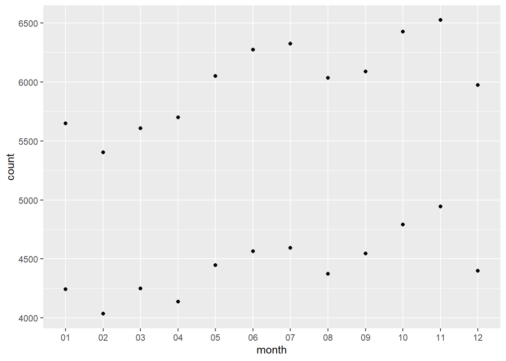

```r
accidents$Date <- as.Date(accidents$Date,format='%d/%m/%Y')
accidents$month <- accidents$Date %>% format('%m')

accidents_date_plot <- accidents %>% group_by(month) %>% summarise(count=n())

ggplot() + geom_point(data=casualties_date_plot,aes(x=month,y=count)) + geom_point(data=accidents_date_plot,aes(x=month,y=count))
```

As you can see from the point chart, count of casualties are overall higher than accidents. Both however follow a similar pattern where both are lowest in Feb and highest in November.

### Q3

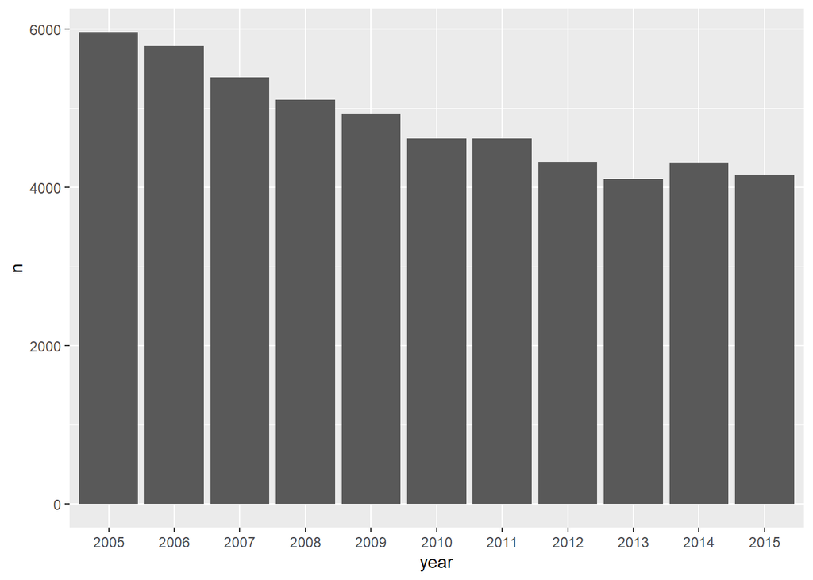

```r
accidents$year <- as.Date(accidents$Date,format='%d/%m/%Y') %>% format('%Y')

accidents_year_plot <- accidents %>% group_by(year) %>% filter(year>= 2005 & year<= 2015) %>% tally()

ggplot(accidents_year_plot) + geom_col(aes(x=year,y=n))
```

Accident rates seem to decline from year 2005 to year 2015. This indicates that there is better road safety done over the years.

### Q4

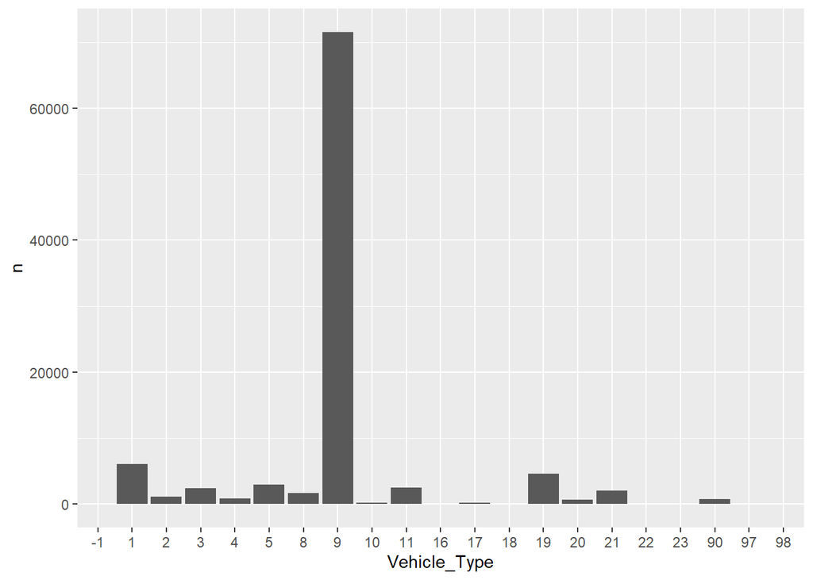

```r
vehicles$Vehicle_Type <- as.factor(vehicles$Vehicle_Type)

vehicles_type_plot <- vehicles %>% group_by(Vehicle_Type) %>% tally()

ggplot(vehicles_type_plot) + geom_col(aes(x=Vehicle_Type,y=n))
```

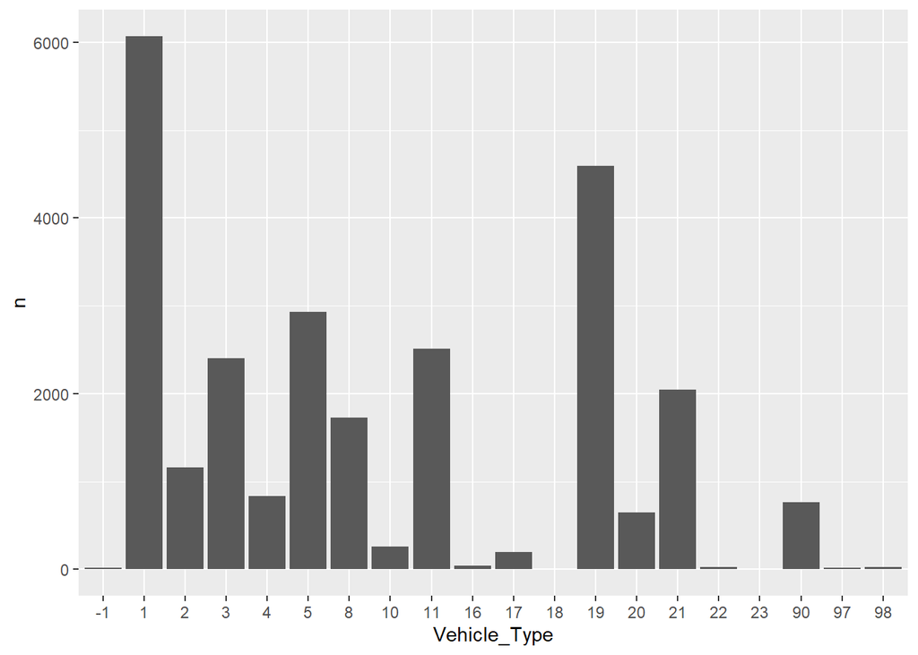

```r
vehicles_type_plot2 <- vehicles %>% group_by(Vehicle_Type) %>% tally() %>% filter(n<=20000)

ggplot(vehicles_type_plot2) + geom_col(aes(x=Vehicle_Type,y=n))
```

Two graphs plots, the first indicates that vehicle type for cars are the highest. After filtering out cars, we can see that the second highest accident vehicle type is pedal cycles.

### Q5

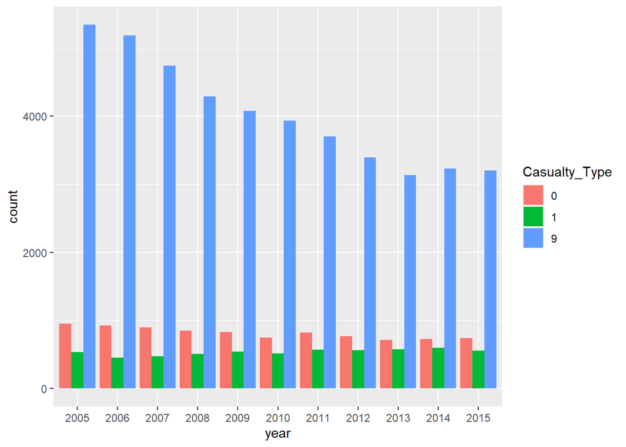

```r
casualties_date$year <- as.Date(casualties_date$Date,format='%d/%m/%Y') %>% format('%Y')
casualties_date$Casualty_Type <- as.factor(casualties_date$Casualty_Type)


casualty_type_plot <- casualties_date %>% filter(Casualty_Type == 0 | Casualty_Type == 1 | Casualty_Type == 9) %>% group_by(year)

ggplot(casualty_type_plot) + geom_bar(aes(x=year,fill=Casualty_Type),position = 'dodge')
```

### Q7

```r
location <- accidents[!is.na(accidents$Longitude) & !is.na(accidents$Latitude), c(4,5)]

m <- leaflet(location) %>%
  setView(lat = 51.513988, lng = -0.207623, zoom = 10) %>%
  addProviderTiles(providers$CartoDB.DarkMatter) %>%
  addWebGLHeatmap(lng=~Longitude, lat=~Latitude, size =1500)
m
```

[interactive chart not shown]

Heatmap for accidents. Years was not provided.

### Q8

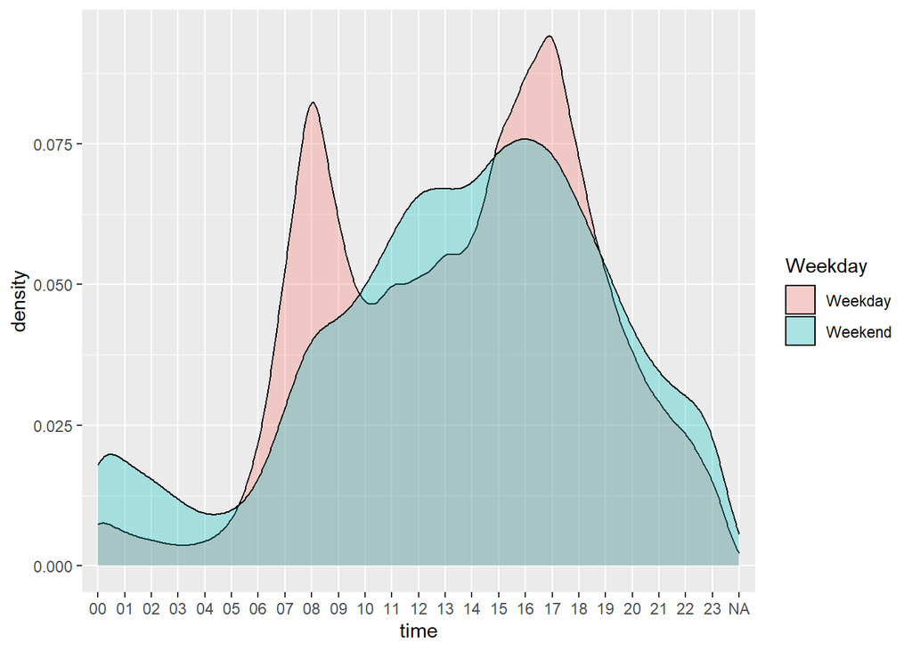

```r
accidents$Day_of_Week <- as.factor(accidents$Day_of_Week)
accidents$Weekday <- 'Weekday'
accidents$Weekday[accidents$Day_of_Week == 1 | accidents$Day_of_Week == 6 |accidents$Day_of_Week == 7] <- 'Weekend'
accidents$time <- strptime(accidents$Time,format='%H:%M') %>% format('%H')

accidents_time <- accidents %>% group_by(time) %>% tally()

accidents %>% ggplot(aes(x=time)) + geom_density(aes(x=time,group=Weekday,fill=Weekday),alpha=0.3)+
  theme(plot.title = element_text(hjust=0.5, face="bold"))
```

From the graph, we can see that for weekdays tend to have more accidents occuring at 7 to 8 am and 4 to 5pm. For the weekends however, accidents appear mostly form the 12pm to 5pm mark.

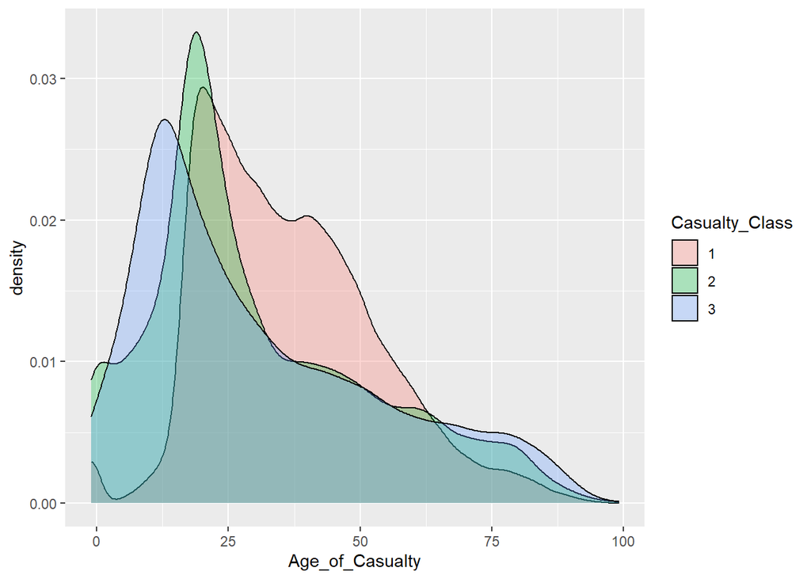

```r
casualties$Age_of_Casualty <- as.numeric(casualties$Age_of_Casualty)
casualties$Casualty_Class <- as.factor(casualties$Casualty_Class)

casualties %>% ggplot(aes(x=Age_of_Casualty)) + geom_density(aes(x=Age_of_Casualty,group=Casualty_Class,fill=Casualty_Class),alpha=0.3)+
  theme(plot.title = element_text(hjust=0.5, face="bold"))
```

Form the graph, we can see that for difference casualty types, all three tend to have the highest amount around the 10 to 25 year old mark. For pedestrains, more casualties are found below the age of 25. However for drivers/rides, most are found above the age of 25.